# Лабораторная работа № 2

Управление пользователями и группами

Павличенко Родион Андреевич

1132246838@pfur.ru

Российский университет дружбы народов

2025-06-09

# Информация

## Докладчик

- Павличенко Родион Андреевич
- Cтудент
- Группа НПИбд-02-24
- Российский университет дружбы народов им. П. Лумумбы
- 1132246838@pfur.ru

# Выполнение лабораторной работы

## Выполняем команду и получаем более подробную информацию и нашей учетной записи, используя команду id. Основная группа моего пользователя gid=1000(rapavlichenko), также есть второстепенная группа wheel

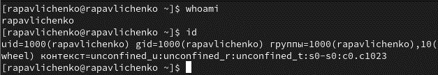

## Переключились на учетную запись root при помощи команды su, набрали команду id, вернулись к своей учетной записи командой su rapavlichenko . Получены сведения: uid=0(root) — идентификатор пользователя root (всегда 0), gid=0(root) — идентификатор основной группы root (также 0). группы=0(root) — пользователь root входит в группу root.

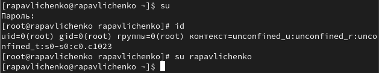

## При помощи команды sudo -I visudo открыли файл и убедились, что в текущем файле есть строка %wheel ALL=(ALL) ALL

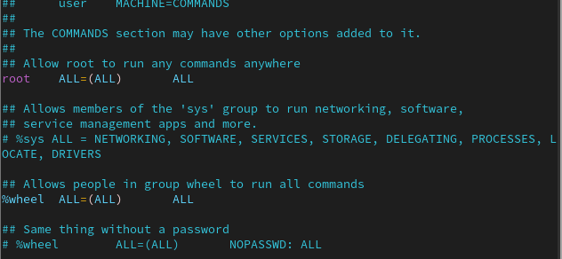

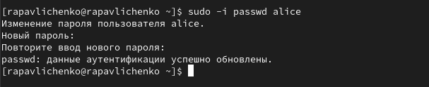

## Перешли в учетную запись alice командой su alice, создали пользователя bob и задали для него пароль, просмотрели командой id в какие группы он входит

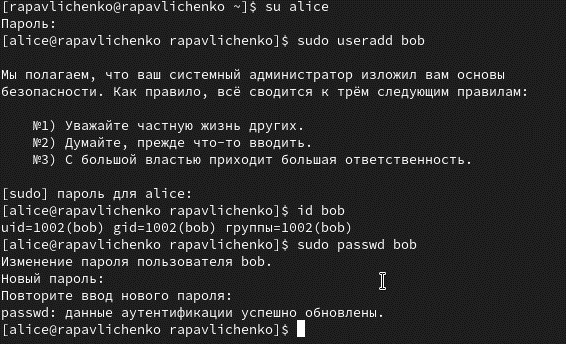

## Переключились на учетную запись пользователя root и открыли файл

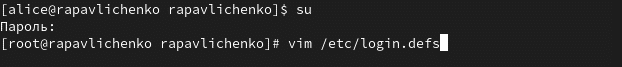

## Изменили параметры CREATE_HOME и USERGROUPS_ENAB

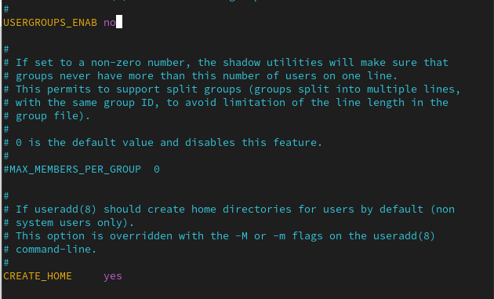

## Перешли в каталог /etc/skel и создали два каталога Documents и Pictures

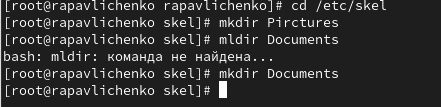

## При помощи nano открываем файл .bashrc и добавляем строку export EDITOD=/usr/bin/vim

## Создали пользователя carol, задали для него пароль

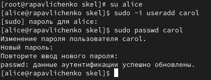

## Просмотрели информацию о пользователе carol , его id 1003, для него не создается отдельная группа, он находится в users, каталоги для него были созданы

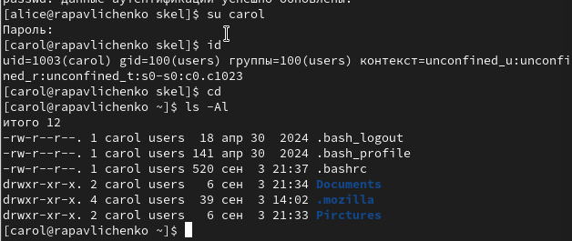

## Просмотрели данные о пароле пользователя carol , увидели пароль в зашифрованном виде и время через которое пароль станет недействительным

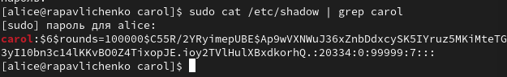

## Меняем параметры пароля и просматриваем изменения

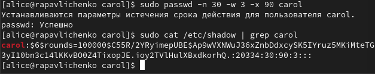

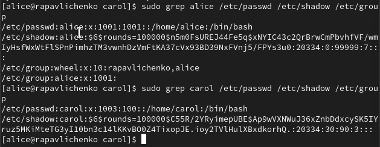

## Создаем две группы – main и third, туда добавляем пользователей alice, bob и carol

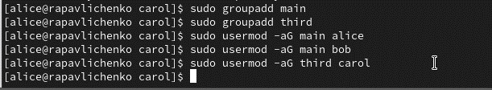

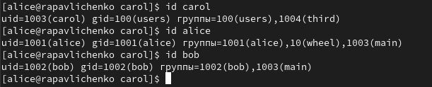